## Introdukson til økonomisk vekst

- Vi er opptatt av økonomisk vekst i et land, fordi dette øker velstandsnivået blant landets innbyggere over tid
- Det er vanlig å måle et lands velstandsnivå ved å dele BNP $Y$ på antall innbyggere i landet $N$, dvs $Y/N$
- Målinger av dette finnes for de fleste land i verden: tabell fra Wikipedia

### Empiriske observasjoner over tid

- Rike land: Har vokst og BNP per innbygger mellom land har konvergert (dvs. mindre forskjeller).
  - Prediksjonen er i tråd med Solow-modellen for økonomisk vekst
- Fattige land: Finner ingen slik klar sammenheng
  - Hypoteser: (1) Geografi, (2) Kultur, **(3) Institusjoner**

[figure not shown]

### Inklusive og ekstraktive offentlige institusjoner (Acemoglu and Robinson 2013)

Institusjonene kan kalles **ekstraktive** dersom en elite (vanligvis i form av et totalitært regime) benytter disse til å ekstrahere verdier fra flertallet.

Institusjonene kan kalles **inklusive** dersom de sørger for privat eiendomsrett, borgerrettigheter, upartisk rettsvesen, fri etableringsrett og karrierevalg

**Øvelse**: Les artikkelen Venezuela Is Starving Its People og noter ned de eksemplene du finner på ekstraktive institusjoner

## Solow-modellen for økonomisk vekst

Solow-modellen har som bakteppe en økonomi med **inklusive** institusjoner. I tillegg kan vi konkretisere følgende forutsetninger:

- Lukket økonomi uten offentlig sektor, $Y = C + I$
- Full konkurranse i kapital- og arbeidsmarkedet (innsatsfaktoren avlønnes etter sin grenseproduktivitet)
- Hele befolkningen er sysselsatt (ingen arbeidsledighet), $L=N$
- Produktfunksjonen er homogen av grad én (dobling av innsatsfaktorene fører til dobling av produksjonen)
- Homogen arbeidskraft (alle arbeiderne har like kvalifikasjoner)
- Befolkningen i landet vokser med en konstant rate, $\frac{\dot{N}}{N}=n$

### Modellens tre komponenter

1. Produktfunksjonen

$$Y=F(K,AL) \text{ } F_{K}>0, F_{KK}<0, F_{L}>0, F_{LL}<0$$
- Produktfunksjon er homogen av grad én (konstant skalutbytte). Som betyr at en t-dobling av innsatsfaktorene medfører en t-dobling av produksjonen
$$tY=tF(K,L)=F(tK,tL)$$

Som betyr at en t-dobling av innsatsfaktorene medfører en t-dobling av produksjonen

- Setter vi $t=\frac{1}{AL}$ får vi $\frac{Y}{AL}=F(\frac{K}{AL},1)$. Definerer vi $y \equiv \frac{1}{AL}$ og $F(K/AL,1) \equiv f(k)$, kan vi skrive produktfunksjone på intensiv form som

$$y=f(k) \text{ } f'{k}>0, f''{k}<0$$

$\text{2.}$ Sparing

$$S=sY=I$$
3. Kapitalakkumalasjon

$$\dot{K}=-\delta K + I$$

### Forenklet Solow-modell

- Ingen teknologisk framgang, $A=1$

Starter med å dele $(3)$ på $K$ og setter inn for $I$ fra (2)

$$\frac{\dot{K}}{K} = -\delta + \frac{sY}{K}= -\delta + \frac{sY/N}{K/N}= -\delta + \frac{sy}{k}$$

$$\frac{\dot{k}}{k} + n = -\delta + \frac{sy}{k}$$

Multipliserer vi uttrykket for $k$ har vi kapitaldynamikkligningen for modellen

#### Modellen

Kapitaldynamikken
$$\dot{k} = sf(k) -(\delta +n) k$$

Avlønning til kapitalen (viser dette på seminaroppgaven):
$$r = f'(k)- \delta$$

Avlønning til arbeidskraften (viser dette på seminaroppgaven):
$$w = (f(k) - f'(k)k)$$

#### Modellens sentrale prediksoner

- $sf(k)> (\delta+n) k$ vil **BNP per arbeidskraftenhet** vokse, og veksten vil være stærkere desto lavere nivået er på $k$
- $sf(k)< (\delta+n) k$ vil **BNP per arbeidskraftenhet** synke, og reduksjonen vil være stærkere desto lavere nivået er på $k$
- På lang sikt og uavhengig av startverdiren for $k_{0}$, vil økonomien konvergere mot en stasjonær-tilstand (steady-state) hvor produksjonen per innbygger er konstant, c.

Disse resultatene er overens med hva som ble beskrevet innledningsvis: BNP per innbygger har vokst og konvergert (dvs. mindre forskjeller) mellom land med inklusive institusjoner.

### Solow-modellen (normalversjonen)

Modellen vil her være gitt ved (i neste seminar skal vi se nærmere på hvordan vi løser dette matematisk):

$$\Delta{k} = sf(k)-(\delta+n+ a) k$$
Avlønning til kapitalen:
$$r = f'(k)- \delta$$

Avlønning til arbeidskraften:
$$w = A\cdot (f(k) - f'(k)k)$$

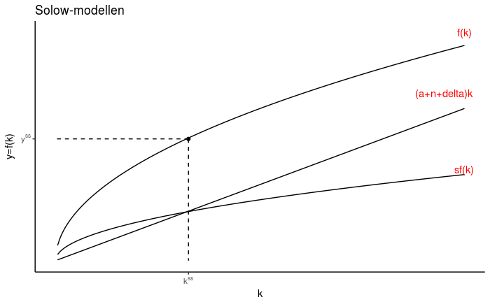

#### Modellens sentrale prediksjoner

- $sf(k)> (\delta+n+ a)k$ vil **BNP per effektiv arbeidskraftenhet** øke, og veksten vil være stærkere desto lavere nivået er på $k$
- $sf(k) < <(\delta+n + a) k$ vil **BNP per effektiv arbeidskraftenhet** reduseres, og reduksjonen vil være stærkere desto lavere nivået er på $k$
- På lang sikt og uavhengig av startverdiren for $k_{0}$, vil økonomien konvergere mot en stasjonær-tilstand (steady-state) hvor produksjonen per innbygger vokser med en eksogen (bestemt utenfor modellen) rate lik **$a$**
  - Merk: Dette medfører at trendveksten (som har benyttet i konjunkturanalysen i del I) i stasjonærtilstanden er gitt ved:
    $$\frac{Y}{AN}=c \Rightarrow ln(Y) - ln(N) - ln(A) = ln(c) \Rightarrow \dot{Y}/Y = n + a$$

**Øvelse (blir også gitt til seminaret)**: Les artikkelen Economists vs. Scientists on Long-Term Growth og gi en kortfattet oversikt over hvilken faktorer som vil påvirke teknologiparameteren $a$ framover.

#### Skiftanalyse

- Økt sparerate

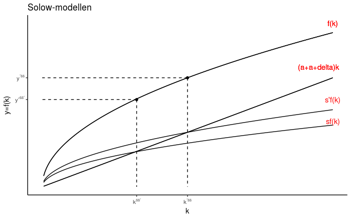

# Referanser

Acemoglu, Daron, and James A Robinson. 2013. *Why Nations Fail: The Origins of Power, Prosperity, and Poverty*. Broadway Business.